# Order of Entities

The order in which the attribute tables – or entities – appear in the ERD is determined by how the relationships are established. This example illustrates how an ERD with three entities can be rendered differently. The data is from bills in the US senate, which were downloaded using the package [`incidentally`](https://www.zacharyneal.com/incidentally). The complete and commented script is presented at the end.

## US Senate Bills

For this example, US Senate bill data for Session 115 were utilized; they were downloaded with the [`incidentally`](https://www.zacharyneal.com/incidentally) package. The data were pre-processed to have a convenient rectangular structure. The first five records of the three tables are displayed below.

Senators

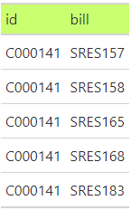

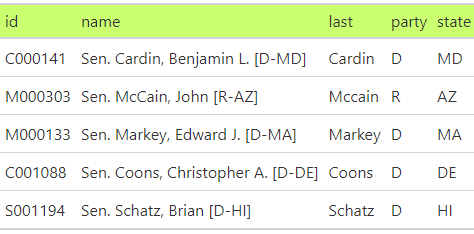

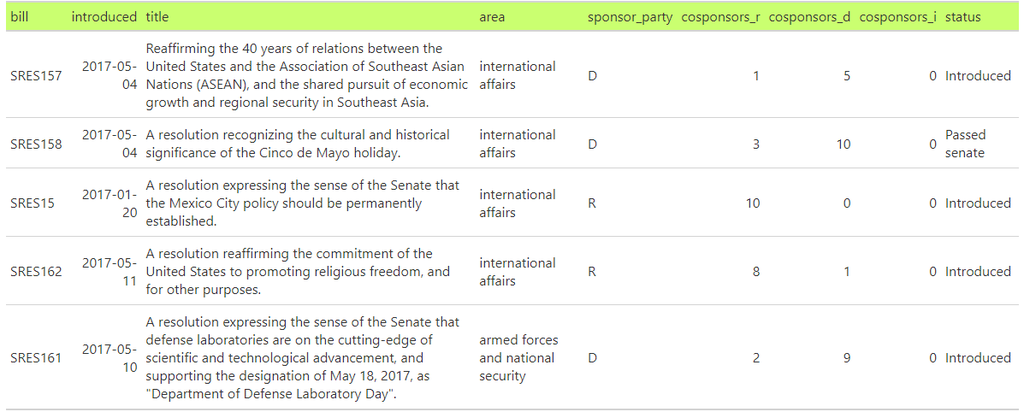

## ERDs

There are three entities: cosponsors, legislators, and bills. The cosponsor’s data is linked to legislators and bills, but legislators and bills are not directly related.

Figure 1 was produced by linking the cosponsors’ table to legislators and bills in the relationships list, like in the code below. The complete example is in the code section.

```r
relationships <- list(
  Cosponsors = list(
    Legislators = list(id = "id", relationship = c(">0", "||")),
    Bills = list(bill = "bill", relationship = c(">|", "||"))
  )
)
```

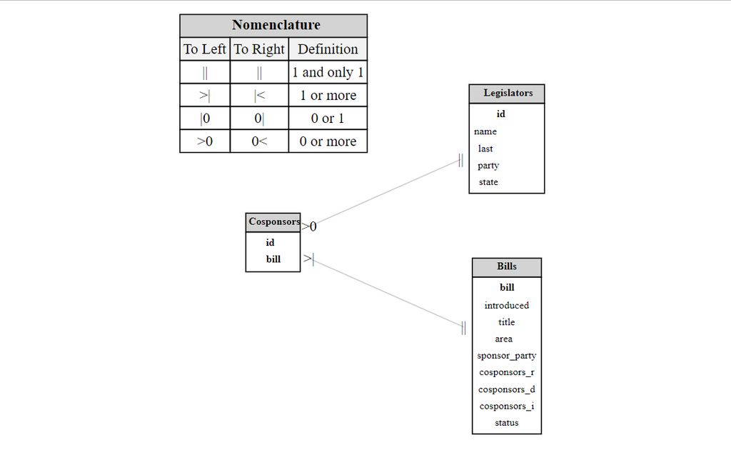

Figure 1: ERD 1.

Figure 2 links legislators to cosponsors, and cosponsors to bills. This was achieved by linking legislators to cosponsors first, and then cosponsors to bills in the relationships list, shown in the code below. The complete example is in the code section.

```r
relationships <- list(
  Legislators = list(
    Cosponsors = list(id = "id", relationship = c("||", "0<"))
  ),
  Cosponsors = list(
    Bills = list(bill = "bill", relationship = c(">|", "||"))
  )
)
```

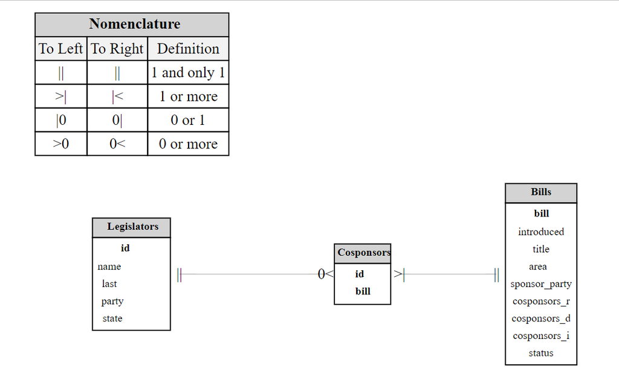

Figure 2: ERD 2.

Finally, Figure 3 was produced in a similar fashion, but in reverse order; the relationships list definition is shown in the code below. The complete example is in the code section.

```r
relationships <- list(
    Bills = list(
    Cosponsors = list(bill = "bill", relationship = c("||", "|<"))
  ),
  Cosponsors = list(
    Legislators = list(id = "id", relationship = c(">0", "||"))
  )
)
```

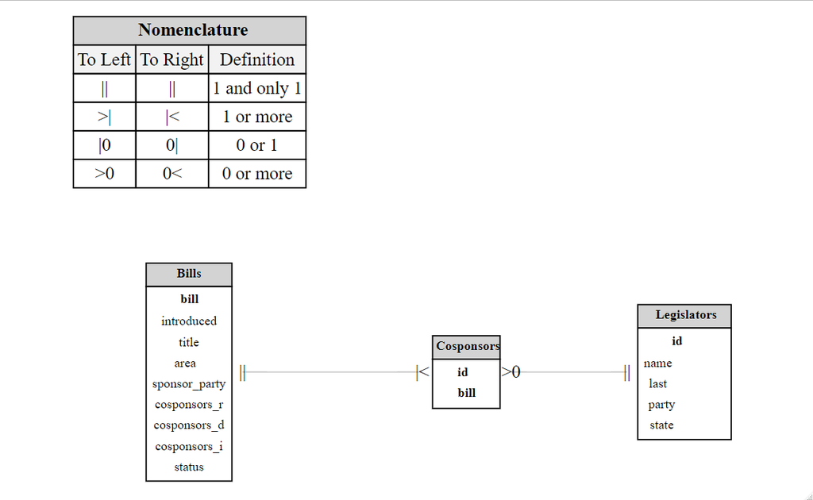

Figure 3: ERD 3

## Code

```r
## Load packages
library(ERDbuilder)
library(incidentally)
library(janitor)
library(dplyr)
library(tidyr)
library(tibble)
library(gt)

# https://cran.r-project.org/web/packages/incidentally/vignettes/congress.html

## Download data for example
I <- incidence.from.congress(
  session = 115,
  types = c("sres"),
  areas = c("All"),
  format = "data",
  narrative = TRUE)


## Define entities. Cosponsors table required some formatting.
legislators_tbl <- I$legislator |> as_tibble()
bills_tbl <- I$bills |> as_tibble() |> clean_names()
cosponsors_tbl <-
  I$matrix |>
  as.data.frame() |>
  rownames_to_column(var = "name") |>
  pivot_longer(-name, names_to = "bill", values_to = "sponsored") |>
  filter(sponsored == 1) |>
  left_join(legislators_tbl, by = join_by(name)) |>
  select(id, bill)

## Show the first five records of every entity
my_gt <- function(df) {
  df |>
    gt() |>
    tab_style(
      style = cell_fill(color = "darkolivegreen1"),
      locations = cells_column_labels()
    )
}

gt_group(
  cosponsors_tbl |> head(5) |> my_gt(),
  legislators_tbl |> head(5) |> my_gt(),
  bills_tbl |> head(5) |> my_gt()
)


## Figure 1
## Define first ERD: cosponsors linked to bills and legislators
relationships <- list(
  Cosponsors = list(
    Legislators = list(id = "id", relationship = c(">0", "||")),
    Bills = list(bill = "bill", relationship = c(">|", "||"))
  )
)

## Create ERD
erd <- create_erd(
  list(
    Cosponsors = cosponsors_tbl,
    Legislators = legislators_tbl,
    Bills = bills_tbl
  ),
  relationships
)

## Render ERD
render_erd(erd, label_distance = 0)

## Figure 2
###   Legislators -> Cosponsors -> Bills

relationships <- list(
  Legislators = list(
    Cosponsors = list(id = "id", relationship = c("||", "0<"))
  ),
  Cosponsors = list(
    Bills = list(bill = "bill", relationship = c(">|", "||"))
  )
)

erd <- create_erd(
  list(
    Cosponsors = cosponsors_tbl,
    Legislators = legislators_tbl,
    Bills = bills_tbl
  ),
  relationships
)

render_erd(erd, label_distance = 0)

## Figure 3
### Bills -> Cosponsors -> Legislators

relationships <- list(
    Bills = list(
    Cosponsors = list(bill = "bill", relationship = c("||", "|<"))
  ),
  Cosponsors = list(
    Legislators = list(id = "id", relationship = c(">0", "||"))
  )
)

erd <- create_erd(
  list(
    Cosponsors = cosponsors_tbl,
    Legislators = legislators_tbl,
    Bills = bills_tbl
  ),
  relationships
)

render_erd(erd, label_distance = 0)
```